# ECON6027_3a

Dr. Liu

# Mapping with TMAP

Load the required packages.

```r
# install.packages("tmap", repos = c("https://r-tmap.r-universe.dev", "https://cloud.r-project.org"))
library(sf); library(spData); library(tmap)
```

## TMAP basics

tm_shape() provides the basic building block which accepts input data for the sf object. Layers are added on top to customise the visualisation aesthetics. For example,

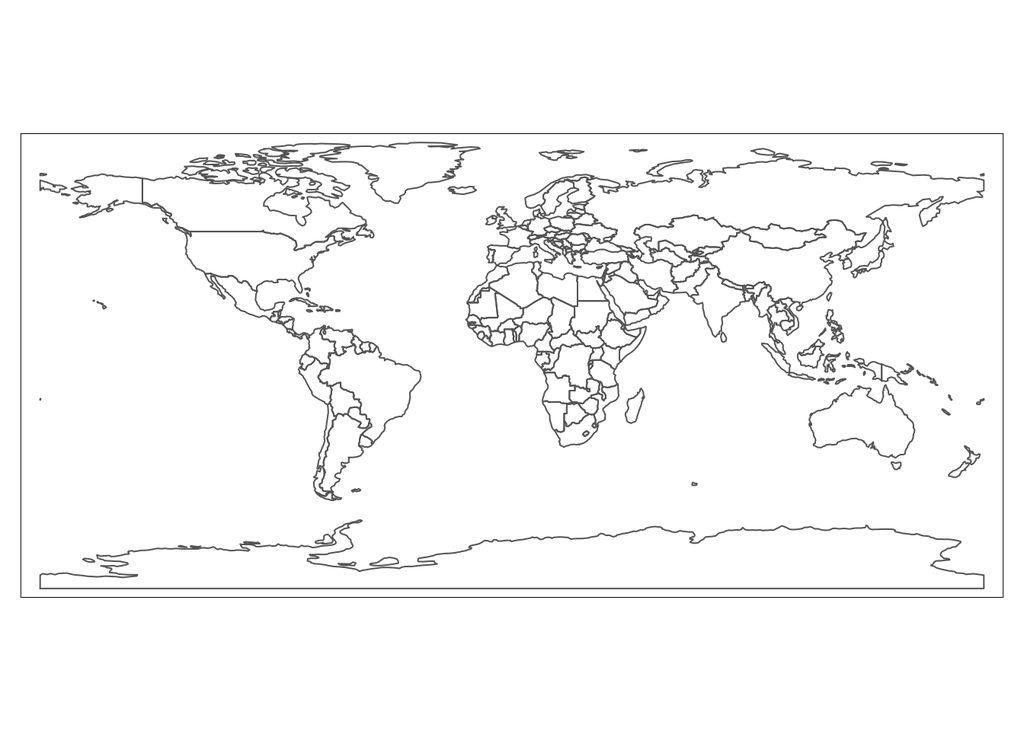

```r
tm_shape(world)+tm_borders()
```

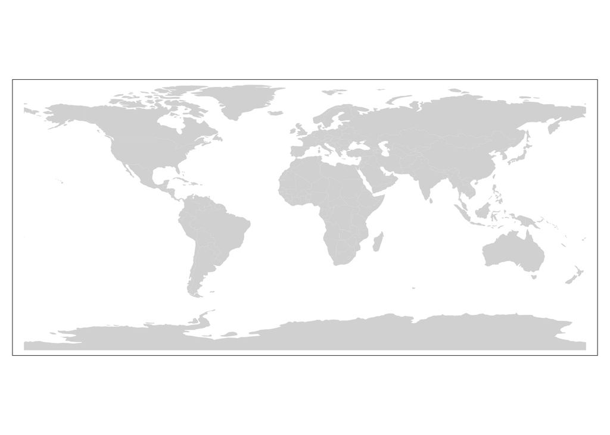

```r
# plot(st_geometry(world))
tm_shape(world)+tm_fill()
```

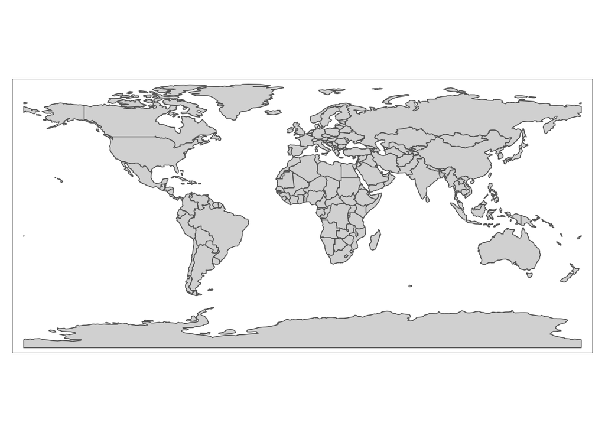

```r
tm_shape(world)+tm_fill()+tm_borders()
```

We can store map objects (known as tmap objects) for later use.

```r
nz # polygon object
```

```
## Simple feature collection with 16 features and 6 fields
## Geometry type: MULTIPOLYGON
## Dimension:     XY
## Bounding box:  xmin: 1090144 ymin: 4748537 xmax: 2089533 ymax: 6191874
## Projected CRS: NZGD2000 / New Zealand Transverse Mercator 2000
## First 10 features:
##                 Name Island Land_area Population Median_income Sex_ratio
## 1          Northland  North 12500.561     175500         23400 0.9424532
## 2           Auckland  North  4941.573    1657200         29600 0.9442858
## 3            Waikato  North 23900.036     460100         27900 0.9520500
## 4      Bay of Plenty  North 12071.145     299900         26200 0.9280391
## 5           Gisborne  North  8385.827      48500         24400 0.9349734
## 6        Hawke's Bay  North 14137.524     164000         26100 0.9238375
## 7           Taranaki  North  7254.480     118000         29100 0.9569363
## 8  Manawatu-Wanganui  North 22220.608     234500         25000 0.9387734
## 9         Wellington  North  8048.553     513900         32700 0.9335524
## 10        West Coast  South 23245.456      32400         26900 1.0139072
##                              geom
## 1  MULTIPOLYGON (((1745493 600...
## 2  MULTIPOLYGON (((1803822 590...
## 3  MULTIPOLYGON (((1860345 585...
## 4  MULTIPOLYGON (((2049387 583...
## 5  MULTIPOLYGON (((2024489 567...
## 6  MULTIPOLYGON (((2024489 567...
## 7  MULTIPOLYGON (((1740438 571...
## 8  MULTIPOLYGON (((1866732 566...
## 9  MULTIPOLYGON (((1881590 548...
## 10 MULTIPOLYGON (((1557042 531...
```

```r
nz_map = tm_shape(nz) + tm_fill() + tm_borders()
class(nz_map)
```

```
## [1] "tmap"
```

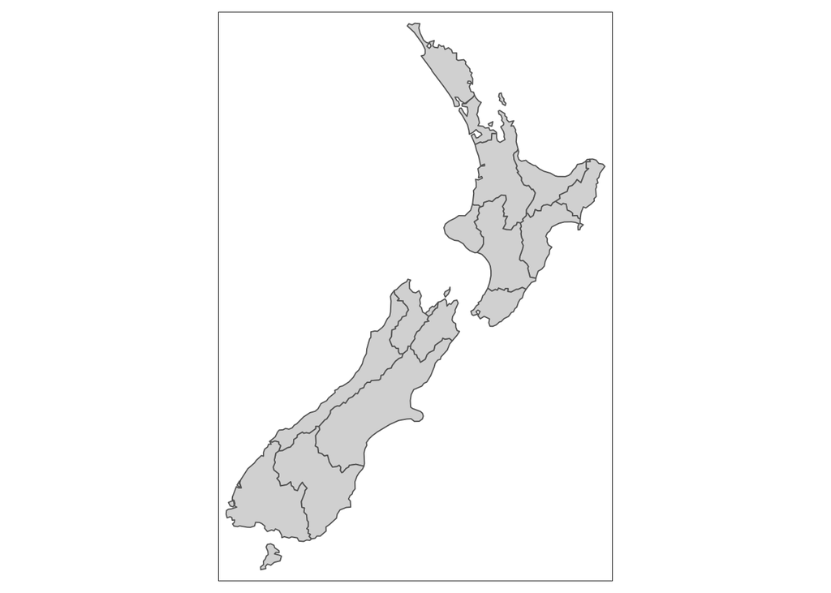

```r
print(nz_map)
```

```r
nz_height # point object
```

```
## Simple feature collection with 101 features and 2 fields
## Geometry type: POINT
## Dimension:     XY
## Bounding box:  xmin: 1204143 ymin: 5048309 xmax: 1822492 ymax: 5650492
## Projected CRS: NZGD2000 / New Zealand Transverse Mercator 2000
## First 10 features:
##    t50_fid elevation                geometry
## 1  2353944      2723 POINT (1204143 5049971)
## 2  2354404      2820 POINT (1234725 5048309)
## 3  2354405      2830 POINT (1235915 5048745)
## 4  2369113      3033 POINT (1259702 5076570)
## 5  2362630      2749 POINT (1378170 5158491)
## 6  2362814      2822 POINT (1389460 5168749)
## 7  2362817      2778 POINT (1390166 5169466)
## 8  2363991      3004 POINT (1372357 5172729)
## 9  2363993      3114 POINT (1372062 5173236)
## 10 2363994      2882 POINT (1372810 5173419)
```

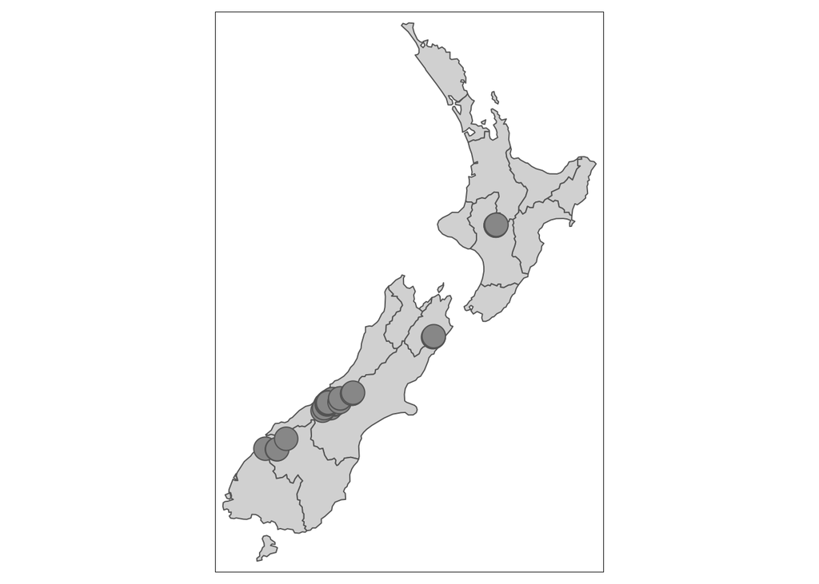

```r
nz.h_map = nz_map + tm_shape(nz_height) + tm_bubbles()
print(nz.h_map)
```

Let us create another object of the territorial waters of nz and plot them together. In the chunk below, we - add the territorial waters (22.2km), - st_union: dissolve borders and combine all polygons, - feed the output to create a buffer, - change the buffer to a LINESTRING and - tmap_arrange() is used to arrange the two maps together.

Notice the use of “chaining” to combine different lines of code into one. When chaining, the output of the previous link is the input for the next, so, we write the code without the input argument in the subsequent links.

```r
nz_water = st_union(nz) %>% st_buffer(22200) %>% st_cast(to = "LINESTRING")
# %>% is called the chain/pipe operator
nz_water # line object
```

```
## Geometry set for 1 feature
## Geometry type: LINESTRING
## Dimension:     XY
## Bounding box:  xmin: 1067944 ymin: 4726340 xmax: 2111732 ymax: 6214066
## Projected CRS: NZGD2000 / New Zealand Transverse Mercator 2000
```

```
## LINESTRING (1074909 4920220, 1074855 4920397, 1...
```

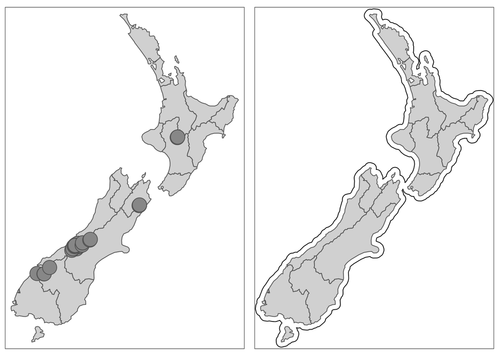

```r
nz.tw_map = nz_map + tm_shape(nz_water) + tm_lines()
# notice the new new tmap element
tmap_arrange(nz.h_map, nz.tw_map)
```

The objects we create using the TMAP package can be saved for later use. tmap_save() is used to to save tmap objects into the directory. Supported extensions: pdf, eps, svg, wmf(Windows only), png, jpg, bmp, tiff, and html.

```r
# tmap_save(tmap_object, 'xx.jpg')
```

## TMAP aesthetics

The empty tmap layers such as tm_fill, tm_borders,tm_lines, tm_bubbles, tm_squares, tm_dots, etc. that created before can be filled with aesthetic arguments.

tm_polygons() plots the geometry column by default. What if you want to plot an attribute other than the geometry column?

```r
head(nz)
```

```
## Simple feature collection with 6 features and 6 fields
## Geometry type: MULTIPOLYGON
## Dimension:     XY
## Bounding box:  xmin: 1568217 ymin: 5518431 xmax: 2089533 ymax: 6191874
## Projected CRS: NZGD2000 / New Zealand Transverse Mercator 2000
##            Name Island Land_area Population Median_income Sex_ratio
## 1     Northland  North 12500.561     175500         23400 0.9424532
## 2      Auckland  North  4941.573    1657200         29600 0.9442858
## 3       Waikato  North 23900.036     460100         27900 0.9520500
## 4 Bay of Plenty  North 12071.145     299900         26200 0.9280391
## 5      Gisborne  North  8385.827      48500         24400 0.9349734
## 6   Hawke's Bay  North 14137.524     164000         26100 0.9238375
##                             geom
## 1 MULTIPOLYGON (((1745493 600...
## 2 MULTIPOLYGON (((1803822 590...
## 3 MULTIPOLYGON (((1860345 585...
## 4 MULTIPOLYGON (((2049387 583...
## 5 MULTIPOLYGON (((2024489 567...
## 6 MULTIPOLYGON (((2024489 567...
```

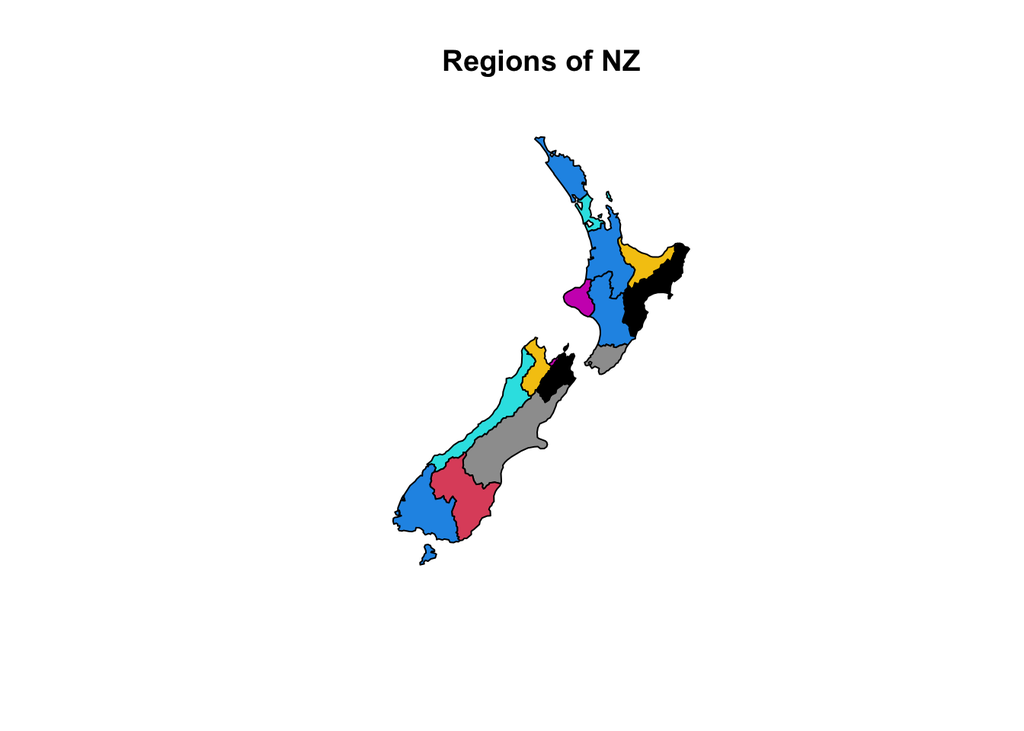

```r
# Basic plot using base R plot function
plot(st_geometry(nz), col = nz$Land_area, main="Regions of NZ")
```

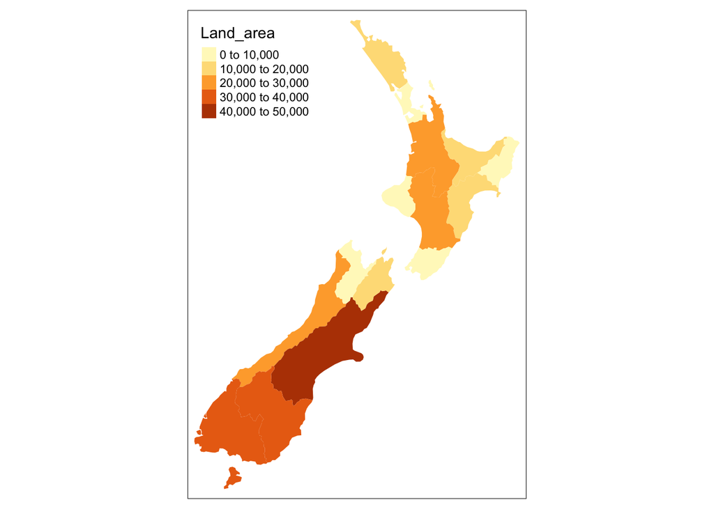

```r
# The same using tmap
tm_shape(nz) + tm_fill(col = "Land_area")
```

```r
# tm_shape(nz) + tm_fill(col = "Land_area") + tm_layout(legend.outside = T)
```

To add legend title (not map title) and change colour palette using “RColorBrewer” package:

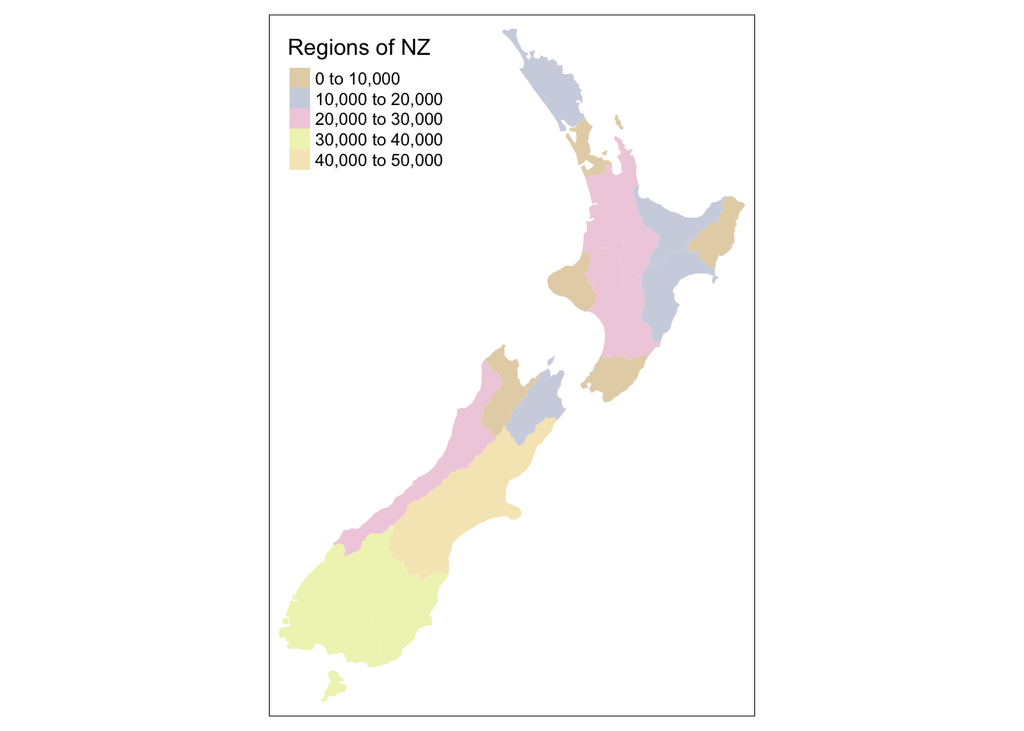

```r
tm_shape(nz) + tm_fill(col = "Land_area", title = "Regions of NZ", palette="Pastel2")
```

```r
# tm_shape(nz) + tm_fill(col = "Land_area", title = "Regions of NZ", palette="Pastel2") + tm_layout(legend.outside = T)
# RColorBrewer::display.brewer.all()
```

To add polygon borders:

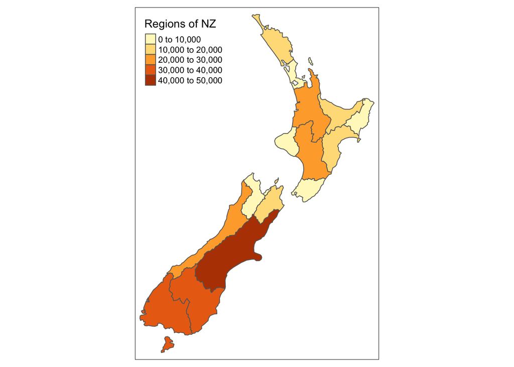

```r
tm_shape(nz) + tm_polygons(col = "Land_area", title = "Regions of NZ")
```

To add a compass and a scale bar:

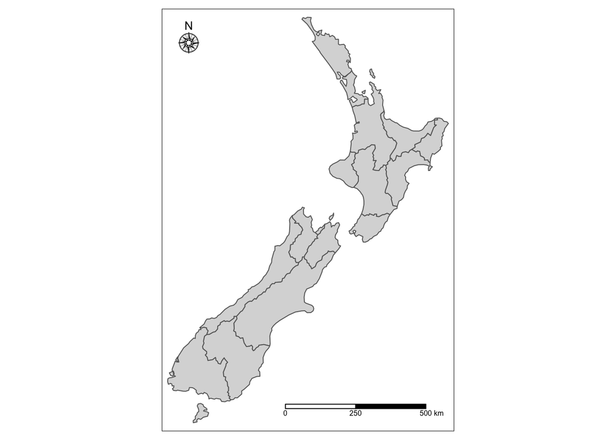

```r
nz_map + tm_compass(type = "rose", position = c("left", "top"), size = 1.5) + tm_scale_bar(breaks = c(0, 250, 500))
```

To add a map title using layout options. The grammar option tm_layout() spells out global options:

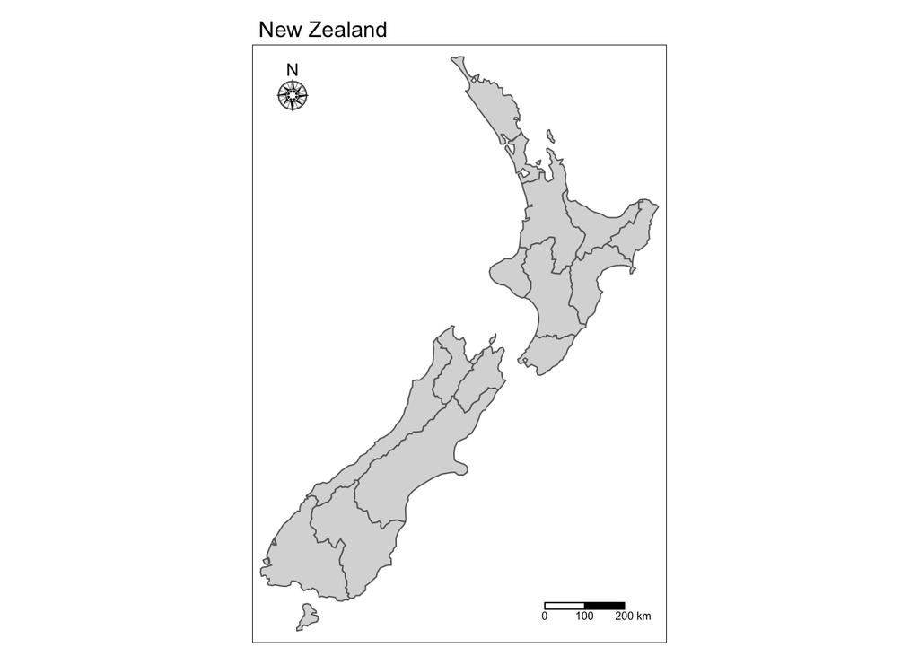

```r
nz_map + tm_compass(type = "rose", position = c("left", "top"), size = 1.5) + tm_scale_bar(breaks = c(0, 100, 200)) + tm_layout(main.title="New Zealand", main.title.size = 1)
```

## Animated maps

```r
asia = world[world$continent=="Asia", ]
asia_maps = tm_shape(asia) + tm_polygons("yellow") + tm_facets(along = "name_long")
```

The package “gifski” is required to create a gif animation. The package “av” is required for video formats. The mp4 format is recommended.

## Interactive maps

Interactivity can take many forms, the most common and useful of which is the ability to pan around and zoom into any part of a geographic dataset overlaid on a ‘web map’ to show context. The most important type of interactivity, is the display of geographic data on interactive web maps.

There are many ways to create interactive maps in R. One way is using the leaflet package. For more information, visit https://rstudio.github.io/leaflet/

```r
nz_map = tm_shape(nz) + tm_polygons()
tmap_mode("view")
```

```
## tmap mode set to interactive viewing
```

```r
nz_map
```

[interactive chart not shown]

```r
tmap_mode("plot")
```

```
## tmap mode set to plotting
```

```r
# or
tmap_leaflet(nz_map)
```

[interactive chart not shown]

The leaflet package allows many base map options provided by different providers inclusing, “OpenTopoMap”, “OpenStreetMap”, “Esri.WorldImagery”, “Esri.WorldTerrain”, “Esri.WorldPhysical”, “Esri.NatGeoWorldMap”, “Esri.OceanBasemap”, etc. To check for the full list of server options run: leaflet::providers.

Use the following chunk to change different base map options. Please note that some base maps are only suitable to specific regions. For example, server “MtbMap” is only suitable when mapping Europe.

```r
tmap_mode("view")
```

```
## tmap mode set to interactive viewing
```

```r
nz_map + tm_basemap(server = "OpenTopoMap") # change server options
```

[interactive chart not shown]

```r
tmap_mode("plot")
```

```
## tmap mode set to plotting
```

## Distorted maps

Another fun thing you can do is to create distorted maps. We will use the package “cartogram”. Using the package functions, geometry is proportionately distorted to represent a mapping variable!

Load the contiguous USA map geography.

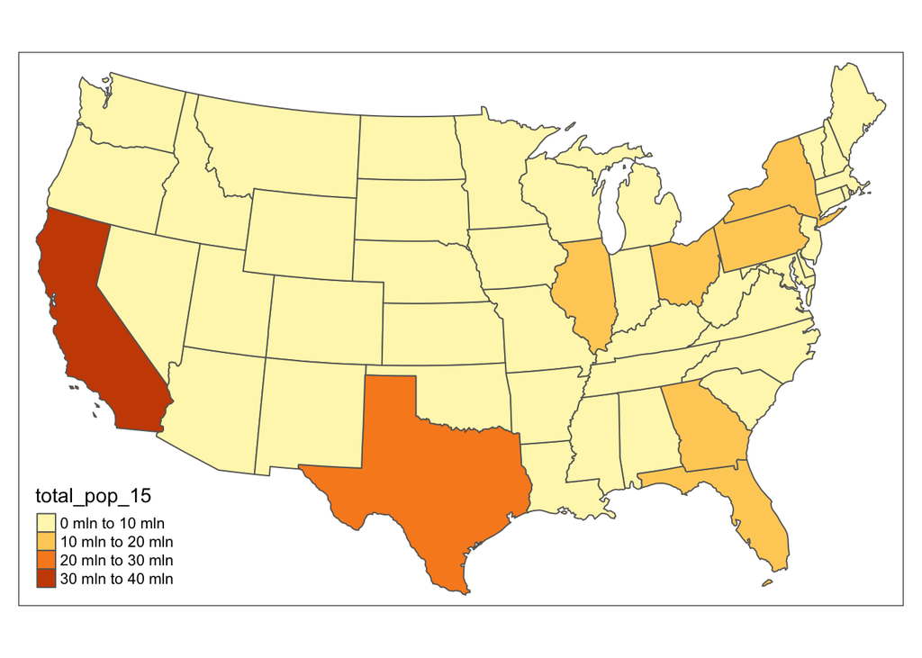

```r
us_states2163 = st_transform(us_states, 2163) # data need to have a projected CRS for tmap.
tm_shape(us_states2163) + tm_polygons("total_pop_15")
```

Apply distortions and plot using the following chunk.

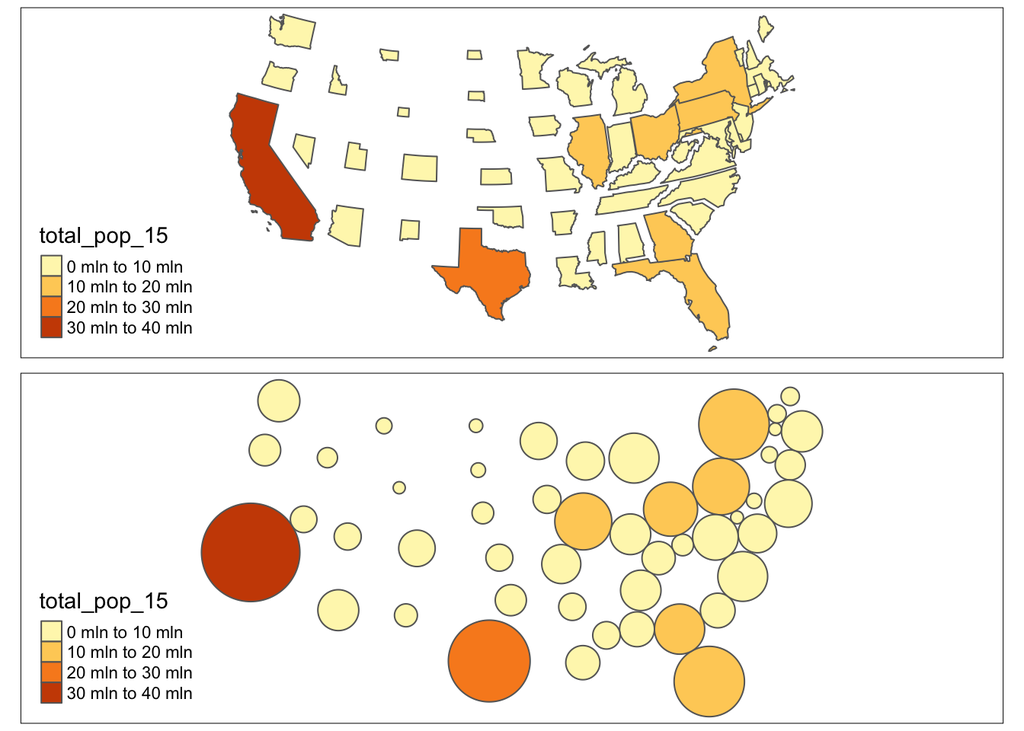

```r
library(cartogram)
us_states2163_ncont = cartogram_ncont(us_states2163, "total_pop_15")
us1 = tm_shape(us_states2163_ncont) + tm_polygons(col="total_pop_15")
us_states2163_bubble = cartogram_dorling(us_states2163, "total_pop_15")
us2 = tm_shape(us_states2163_bubble) + tm_polygons("total_pop_15")
tmap_arrange(us1,us2)
```